# Prob_RWD_Rand_block

Garrick Bruening

# 1 Summary Bar Charts

## 1.1 Effect of Probability

The plot below shows the linear model p-values for just the effect of probability of reward on the metric on the x-axis.

The equation below shows the linear model used:
$$Outcome \sim Probability + (1|Subject)$$

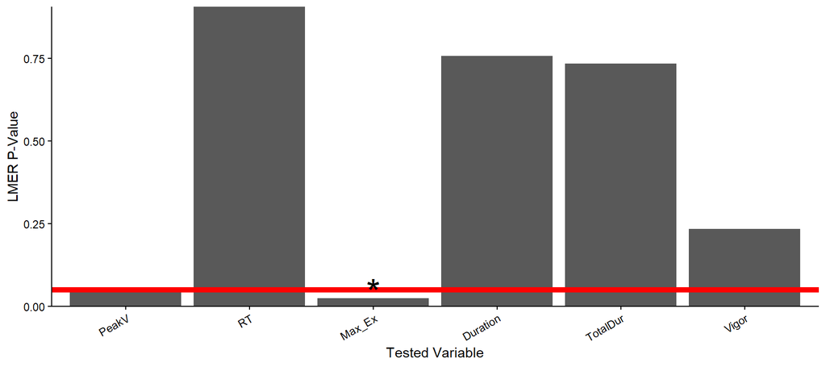

## 1.2 Prior Reward

The plot below shows a summary of linear model p-values for when we split the metric by prior reward. This is also split into individual linear models with just trials that were prior rewarded, and trials that were not prior rewarded.

The equation below shows the linear model used:
$$Outcome \sim Probability + PriorRWD+Probability*Prior RWD + (1|Subject)$$

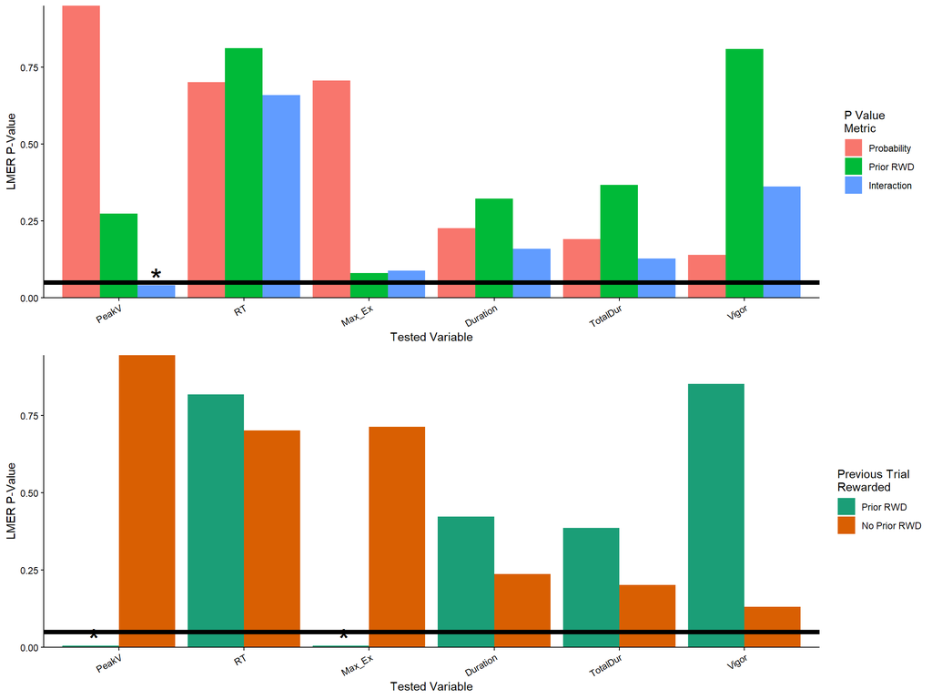

## 1.3 Reward Prediction Error (RPE)

The next plot shows a summary of linear model p-values the prediction of reward prediction error (RPE) when we split the metric by prior reward. This is also split into individual linear models with just trials that were prior rewarded, and trials that were not prior rewarded.

The equation below shows the linear model used:
$$Outcome \sim RPE + PriorRWD+RPE*Prior RWD + (1|Subject)$$

[figure not shown]

# 2 Peak Velocity

## 2.1 Effect of Probability

Peak Velocity WAS NOT significantly affected by probability of reward (p = 5.429e-02, slope = 1.219e-02). This was tested with an LMER with main outcome of probability and random effect of subject.

The equation below shows the linear model used:
$$Outcome \sim Probability + (1|Subject)$$

Table 2.1: Peak Velocity P-Values for effect of Probability

|  | P-Value | Slope | Intercept |
| --- | --- | --- | --- |
| All Target LMER | 5.429e-02 | 1.219e-02 ± 6.334e-03 | 5.673e-01 |
| Target 1/4 LMER | 7.291e-02 | 1.343e-02 ± 7.491e-03 | 5.724e-01 |
| Target 1/4 ANOVA | 9.417e-01 | F val: 6.055e-03 |  |

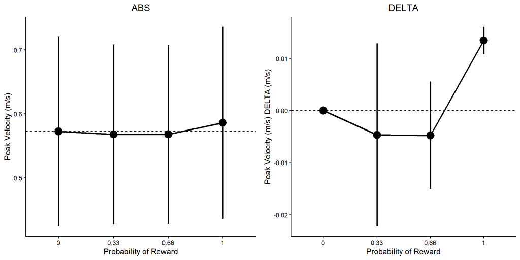

Table 2.2: Paired t-test post hoc comparisons with Holm-Bonferonni correction for Peak Velocity.

|  | 1/3 | 2/3 | 1 |
| --- | --- | --- | --- |
| 0 | 1 | 1 | 0.146 |
| 1/3 | NA | 1 | 1 |
| 2/3 | NA | NA | 0.87 |

These are the uncorrected paired t-test values

Table 2.3: Paired t-test, no correction, for Peak Velocity.

|  | 1/3 | 2/3 | 1 |
| --- | --- | --- | --- |
| 0 | 0.776 | 0.629 | *0.0244 |
| 1/3 | NA | 0.992 | 0.314 |
| 2/3 | NA | NA | 0.174 |

#### 2.1.0.1 Summary Tables

Table 2.4: Summary data table for Peak Velocity. Each row is a probability metric. This is compute subject average for each probability, then average the average. Data is shown as mean ± standard error (lower bound, upper bound) for the 95% confidence interval of that mean.

|  | Mean ± SE (lb, ub) |
| --- | --- |
| 0 | 0.572 ± 0.33 (-0.0753, 1.22) |
| 0.33 | 0.568 ± 0.328 (-0.0747, 1.21) |
| 0.66 | 0.568 ± 0.328 (-0.0747, 1.21) |
| 1 | 0.586 ± 0.338 (-0.0771, 1.25) |

#### 2.1.0.2 Comparison of 0% and 100% Reward

In a paired t test of subject averages, there WAS a significant difference between 0% and 100% reward conditions for Peak Velocity (p = 2.436e-02). .

In a ANOVA test of subject averages, there WAS NOT a significant difference between 0% and 100% reward conditions for Peak Velocity (p = 9.417e-01). .

## 2.2 Effect of Trial

Over the course of the experiment, Peak Velocity INCREASED with each subsequent trial. This was tested using an LMER of the form: Peak Velocity = B*Trial + (1|Subject). We found B = 2.470e-04 and a p-value = 0.000e+00, and an intercept of 4.804e-01

The linear model used to predict effect of trial is shown below:
$$Outcome \sim B*Trial + (1|Subject)$$

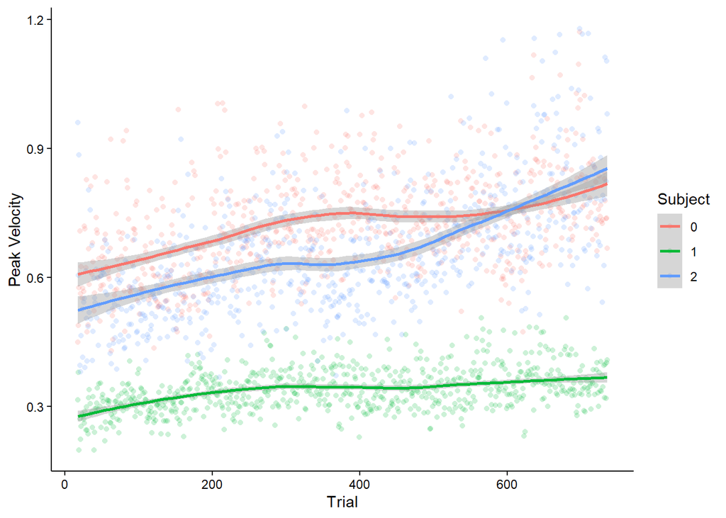

## 2.3 Peak Velocity Following Reward

Using a paried t test, across subjects, the Peak Velocity in trials following rewarded trials WAS NOT statistically different than trials following nonrewarded tirlas (p = 2.287e-01)

Using an ANOVA test, across subjects, the Peak Velocity in trials following rewarded trials WAS NOT statistically different than trials following nonrewarded tirlas (p = 9.817e-01)

Table 2.5: Peak Velocity P-Values for effect of Probability

|  | P-Value |
| --- | --- |
| T-test | 2.287e-01 |
| T-Test Prior==1 | 4.053e-02 |
| T-Test Prior==0 | 3.956e-02 |

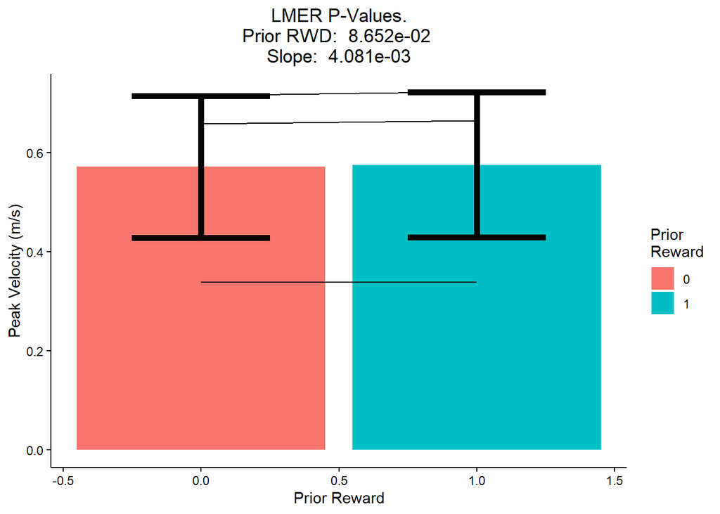

In an interacation LMER of probability of reward and prior reward with subject as a random intercept effect, Peak Velocity WAS NOT affected by probability of reward (p = 9.502e-01) and WAS NOT affected by prior reward (p = 2.744e-01). An interaction of the two factors DID affect Peak Velocity (p = 4.167e-02)

Dividing the data set into two groups (trials following reward and trials not following reward) resulted in finding a significant slope of probability (p = 5.771e-03) in trials that follow reward, but finding NO significant slope (p = 9.445e-01) in trials that do not follow reward.

The linear model used to predict the effect of probability and prior reward is:

$$Outcome \sim Probability + Prior Reward + Probability*Prior Reward + (1|Subject)$$

Table 2.6: Peak Velocity P-Values for effect of Probability

|  | P-Value | Slope |
| --- | --- | --- |
| Intercept | 1.375e-06 | 5.716e-01 ± 1.184e-01 |
| Prob Metric | 9.502e-01 | -5.578e-04 ± 8.934e-03 |
| Prior RWD | 2.744e-01 | -8.600e-03 ± 7.868e-03 |
| Interaction | 4.167e-02 | 2.580e-02 ± 1.266e-02 |
| Lm Prior == 1 Prob Effect | 5.771e-03 | 2.519e-02 ± 9.124e-03 |
| LM Prior == 0 Prob Effect | 9.445e-01 | -6.116e-04 ± 8.793e-03 |

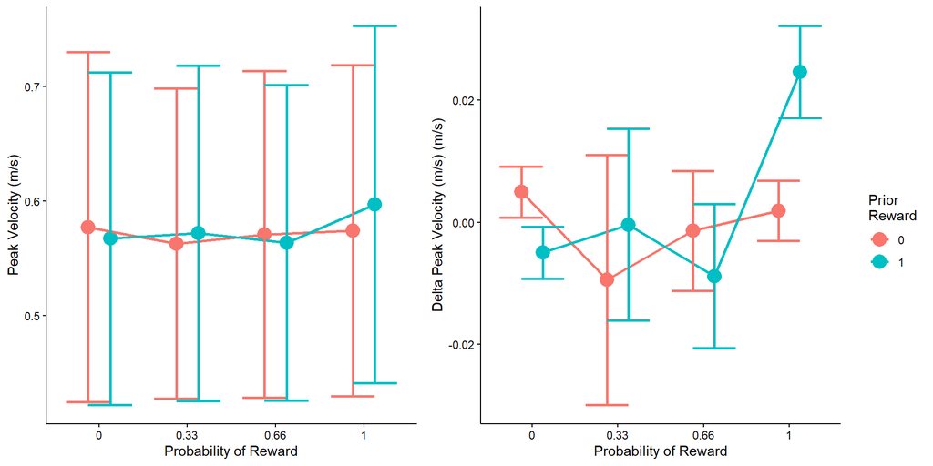

### 2.3.1 Change in Peak Velocity from previous trial due to Reward

Table 2.7: PeakV Diff Prior P-Values for effect of Probability

|  | P-Value |
| --- | --- |
| T-test | 9.762e-01 |
| T-Test Prior==1 | 8.698e-01 |
| T-Test Prior==0 | 9.158e-01 |

To further examine this effect of prior reward on Peak Velocity, the change in Peak Velocity was determined from trial to trial. In the above graph Delta Peak Velocity is the difference in Peak Velocity of the current trial minus the previous trial (PV_(trial=n)-PV_(trial=n-1)). There WAS NOT a statistical difference between trials following and not following reward (paired t-test of subject averages, p = 9.762e-01). Peak Velocity WAS NOT significantly different following reward (t-test of subject averages vs a mean of 0, p = 8.698e-01) and Peak Velocity DID NOT significantly different following trials where they were not rewarded (t-test of subject averages vs a mean of 0, p = 9.158e-01).

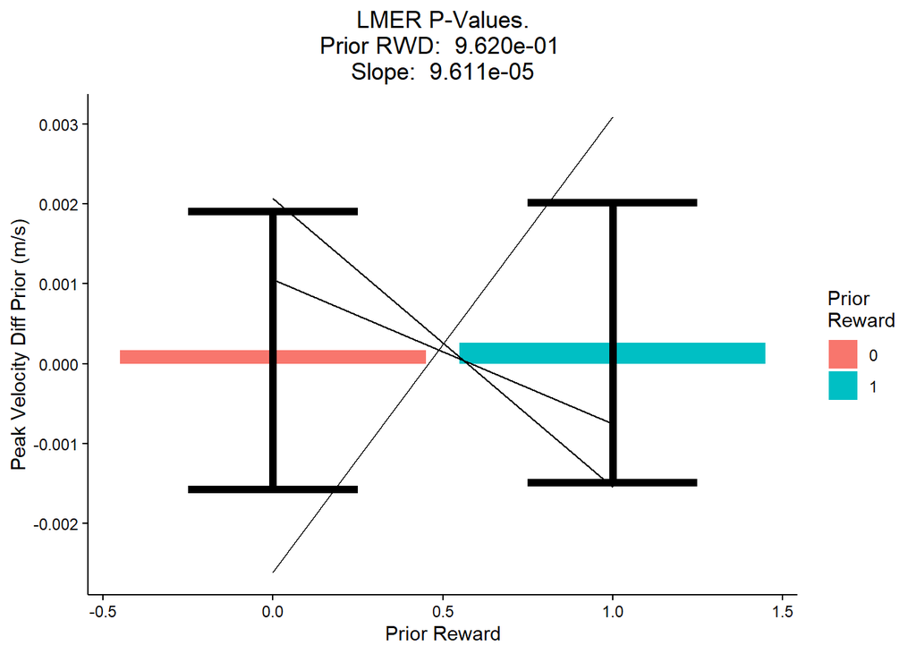

### 2.3.2 Interaction of Prior Reward and Change in Probability of Reward

Table 2.8: PeakV Diff Prior P-Values for effect of Diff Probability

|  | P-Value | Slope |
| --- | --- | --- |
| Intercept | 7.424e-01 | 1.383e-03 ± 4.208e-03 |
| Prob Metric | 5.827e-01 | -4.328e-03 ± 7.878e-03 |
| Prior RWD | 2.227e-01 | 7.295e-03 ± 5.982e-03 |
| Interaction | 2.354e-03 | 3.417e-02 ± 1.123e-02 |
| Lm Prior == 1 Prob Effect | 2.487e-04 | 2.984e-02 ± 8.145e-03 |
| LM Prior == 0 Prob Effect | 5.762e-01 | -4.328e-03 ± 7.744e-03 |

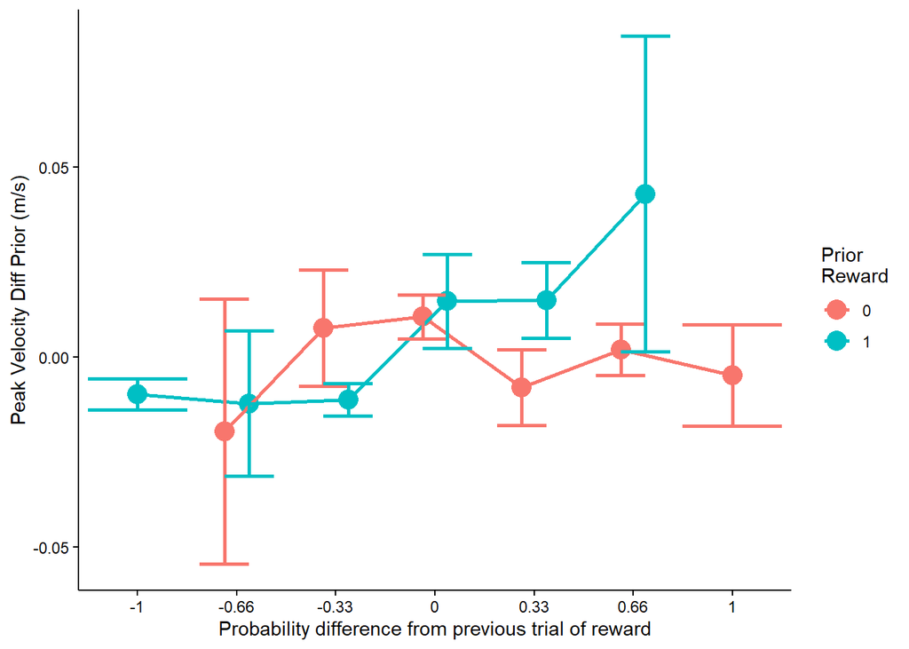

## 2.4 RPE

In an interacation LMER of RPE and prior reward with subject as a random intercept effect, Peak Velocity WAS NOT affected by RPE (p = 2.683e-01) and WAS NOT affected by prior reward (p = 5.122e-01). An interaction of the two factors DID affect Peak Velocity (p = 1.080e-02)

Dividing the data set into two groups (trials following reward and trials not following reward) resulted in finding a significant slope of RPE (p = 1.438e-02) in trials that follow reward, but finding NO significant slope (p = 2.591e-01) in trials that do not follow reward.

Table 2.9: Peak Velocity P-Values for effect of RPE

|  | P-Value | Slope |
| --- | --- | --- |
| Intercept | 4.848e-01 | -3.341e-03 ± 4.781e-03 |
| Prob Metric | 2.683e-01 | -1.614e-02 ± 1.458e-02 |
| Prior RWD | 5.122e-01 | -4.462e-03 ± 6.807e-03 |
| Interaction | 1.080e-02 | 5.273e-02 ± 2.068e-02 |
| Lm Prior == 1 Prob Effect | 1.438e-02 | 3.659e-02 ± 1.495e-02 |
| LM Prior == 0 Prob Effect | 2.591e-01 | -1.614e-02 ± 1.431e-02 |

Table 2.9: Peak Velocity P-Values for effect of RPE

|  | P-Value | Slope | Intercept |
| --- | --- | --- | --- |
| All Target LMER | 4.601e-01 | 5.714e-03 ± 7.734e-03 | 2.130e-04 |
| Target 1/4 LMER | 4.547e-01 | 8.249e-03 ± 1.103e-02 | 4.137e-03 |
| Target 1/4 ANOVA | 3.561e-01 | F val: 9.154e-01 |  |

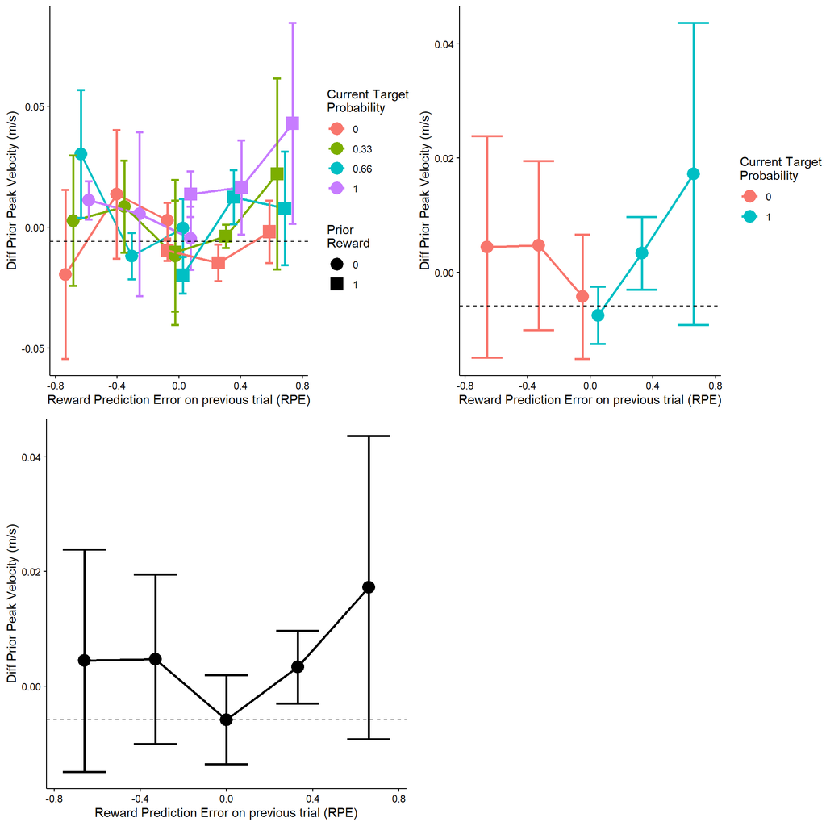

#### 2.4.0.1 T-Tests

Table 2.10: Paired t-test post hoc comparisons with Holm-Bonferonni correction for Peak Velocity Diff Prior (m/s).

|  | -1/3 | 0 | 1/3 | 2/3 |
| --- | --- | --- | --- | --- |
| -2/3 | 1 | 1 | 1 | 1 |
| -1/3 | NA | 1 | 1 | 1 |
| 0 | NA | NA | 1 | 1 |
| 1/3 | NA | NA | NA | 1 |

These are the uncorrected paired t-test values

Table 2.11: Paired t-test, no correction, for Peak Velocity Diff Prior (m/s).

|  | -1/3 | 0 | 1/3 | 2/3 |
| --- | --- | --- | --- | --- |
| -2/3 | 0.993 | 0.576 | 0.937 | 0.759 |
| -1/3 | NA | 0.619 | 0.924 | 0.403 |
| 0 | NA | NA | 0.451 | 0.473 |
| 1/3 | NA | NA | NA | 0.619 |

#### 2.4.0.2 Summary Table RPE

Table 2.12: Summary data table for Diff Prior Peak Velocity. Each row is a probability metric. This is compute subject average for each probability, then average the average. Data is shown as mean ± standard error (lower bound, upper bound) for the 95% confidence interval of that mean.

|  | Mean ± SE (lb, ub) |
| --- | --- |
| -0.66 | 0.00446 ± 0.00258 (-0.000588, 0.00952) |
| -0.33 | 0.00472 ± 0.00272 (-0.000621, 0.0101) |
| 0 | -0.00585 ± -0.00338 (0.00077, -0.0125) |
| 0.33 | 0.00335 ± 0.00194 (-0.000441, 0.00715) |
| 0.66 | 0.0172 ± 0.00995 (-0.00227, 0.0367) |

# 3 Return PeakV

## 3.1 Effect of Probability

```
## fixed-effect model matrix is rank deficient so dropping 1 column / coefficient
## fixed-effect model matrix is rank deficient so dropping 1 column / coefficient
## fixed-effect model matrix is rank deficient so dropping 1 column / coefficient
```

PeakV - Return Peak Velocity WAS significantly affected by probability of reward (p = 1.455e-12, slope = -5.110e-02). This was tested with an LMER with main outcome of probability and random effect of subject.

The equation below shows the linear model used:
$$Outcome \sim Probability + (1|Subject)$$

Table 3.1: PeakV - Return Peak Velocity P-Values for effect of Probability

|  | P-Value | Slope | Intercept |
| --- | --- | --- | --- |
| All Target LMER | 1.455e-12 | -5.110e-02 ± 7.219e-03 | 1.941e-01 |
| Target 1/4 LMER | 2.539e-12 | -5.409e-02 ± 7.726e-03 | 1.992e-01 |
| Target 1/4 ANOVA | 7.917e-01 | F val: 7.974e-02 |  |

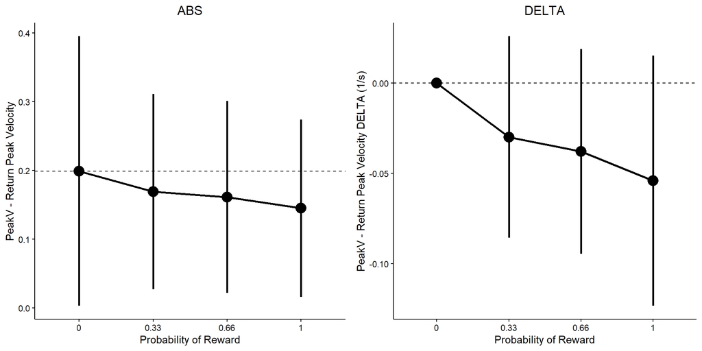

Table 3.2: Paired t-test post hoc comparisons with Holm-Bonferonni correction for PeakV - Return Peak Velocity.

|  | 1/3 | 2/3 | 1 |
| --- | --- | --- | --- |
| 0 | 1 | 1 | 1 |
| 1/3 | NA | 1 | 0.957 |
| 2/3 | NA | NA | 1 |

These are the uncorrected paired t-test values

Table 3.3: Paired t-test, no correction, for PeakV - Return Peak Velocity.

|  | 1/3 | 2/3 | 1 |
| --- | --- | --- | --- |
| 0 | 0.578 | 0.498 | 0.44 |
| 1/3 | NA | 0.289 | 0.16 |
| 2/3 | NA | NA | 0.309 |

#### 3.1.0.1 Summary Tables

Table 3.4: Summary data table for PeakV - Return Peak Velocity. Each row is a probability metric. This is compute subject average for each probability, then average the average. Data is shown as mean ± standard error (lower bound, upper bound) for the 95% confidence interval of that mean.

|  | Mean ± SE (lb, ub) |
| --- | --- |
| 0 | 0.199 ± 0.115 (-0.0262, 0.425) |
| 0.33 | 0.169 ± 0.0977 (-0.0223, 0.361) |
| 0.66 | 0.161 ± 0.0931 (-0.0212, 0.344) |
| 1 | 0.145 ± 0.0838 (-0.0191, 0.309) |

#### 3.1.0.2 Comparison of 0% and 100% Reward

In a paired t test of subject averages, there WAS NOT a significant difference between 0% and 100% reward conditions for PeakV - Return Peak Velocity (p = 4.395e-01). .

In a ANOVA test of subject averages, there WAS NOT a significant difference between 0% and 100% reward conditions for PeakV - Return Peak Velocity (p = 7.917e-01). .

## 3.2 Effect of Trial

Over the course of the experiment, PeakV - Return Peak Velocity INCREASED with each subsequent trial. This was tested using an LMER of the form: PeakV - Return Peak Velocity = B*Trial + (1|Subject). We found B = 4.249e-05 and a p-value = 1.128e-03, and an intercept of 1.527e-01

The linear model used to predict effect of trial is shown below:
$$Outcome \sim B*Trial + (1|Subject)$$

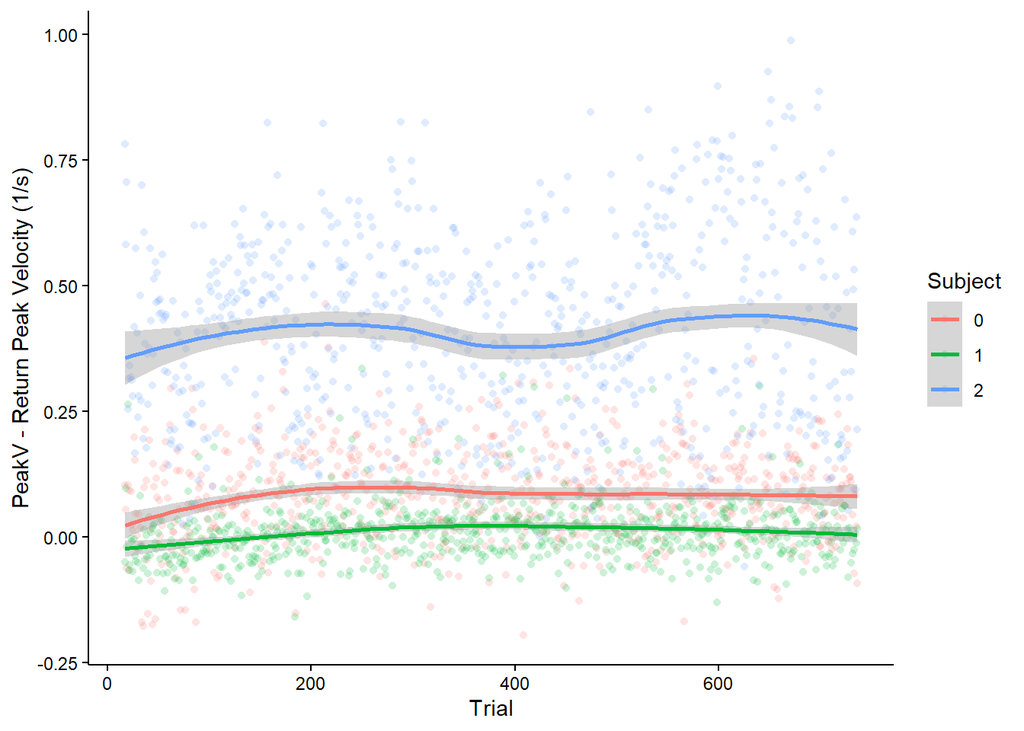

## 3.3 RPE

The linear model used to predict the effect of RPE is:

$$Outcome \sim Probability + (1|Subject)$$
In an LMER of RPE with subject as a random intercept effect, PeakV-ReturnPeakV WAS affected by RPE (p = 0.000e+00).

Table 3.5: PeakV - Return Peak Velocity P-Values for effect of RPE

|  | P-Value | Slope | Intercept |
| --- | --- | --- | --- |
| All Target LMER | 0.000e+00 | -7.154e-02 ± 8.093e-03 | 1.687e-01 |
| Target 1/4 LMER | NA | NA ± NA | 1.722e-01 |
| Target 1/4 ANOVA | NA | F val: NA |  |

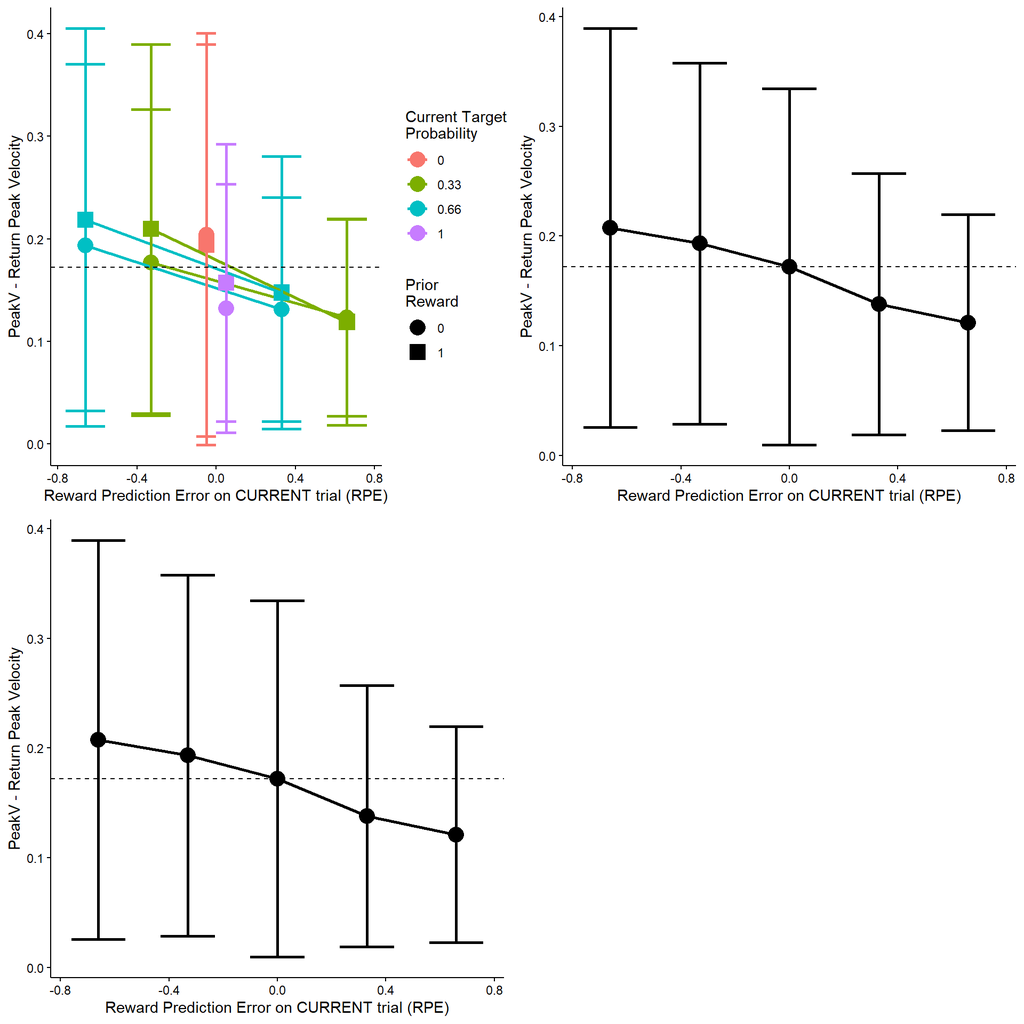

#### 3.3.0.1 T-Tests

Table 3.6: Paired t-test post hoc comparisons with Holm-Bonferonni correction for PeakV - Return Peak Velocity.

|  | -1/3 | 0 | 1/3 | 2/3 |
| --- | --- | --- | --- | --- |
| -2/3 | 1 | 1 | 0.28 | 1 |
| -1/3 | NA | 0.787 | 0.739 | 1 |
| 0 | NA | NA | 1 | 1 |
| 1/3 | NA | NA | NA | 1 |

These are the uncorrected paired t-test values

Table 3.7: Paired t-test, no correction, for PeakV - Return Peak Velocity.

|  | -1/3 | 0 | 1/3 | 2/3 |
| --- | --- | --- | --- | --- |
| -2/3 | 0.931 | 0.161 | *0.028 | 0.389 |
| -1/3 | NA | 0.0983 | 0.0821 | 0.306 |
| 0 | NA | NA | 0.946 | 0.584 |
| 1/3 | NA | NA | NA | 0.657 |

#### 3.3.0.2 Summary Table RPE

Table 3.8: Summary data table for Diff Prior PeakV - Return Peak Velocity. Each row is a probability metric. This is compute subject average for each probability, then average the average. Data is shown as mean ± standard error (lower bound, upper bound) for the 95% confidence interval of that mean.

|  | Mean ± SE (lb, ub) |
| --- | --- |
| -0.66 | 0.208 ± 0.12 (-0.0273, 0.442) |
| -0.33 | 0.193 ± 0.112 (-0.0254, 0.412) |
| 0 | 0.172 ± 0.0994 (-0.0227, 0.367) |
| 0.33 | 0.138 ± 0.0797 (-0.0182, 0.294) |
| 0.66 | 0.121 ± 0.07 (-0.0159, 0.258) |

# 4 Reaction Time

## 4.1 Effect of Probability

```
## boundary (singular) fit: see ?isSingular
```

Reaction Time WAS NOT significantly affected by probability of reward (p = 9.061e-01, slope = -3.252e-04). This was tested with an LMER with main outcome of probability and random effect of subject.

The equation below shows the linear model used:
$$Outcome \sim Probability + (1|Subject)$$

Table 4.1: Reaction Time P-Values for effect of Probability

|  | P-Value | Slope | Intercept |
| --- | --- | --- | --- |
| All Target LMER | 9.061e-01 | -3.252e-04 ± 2.758e-03 | 2.254e-01 |
| Target 1/4 LMER | 9.673e-01 | 1.074e-04 ± 2.618e-03 | 2.264e-01 |
| Target 1/4 ANOVA | 9.836e-01 | F val: 4.781e-04 |  |

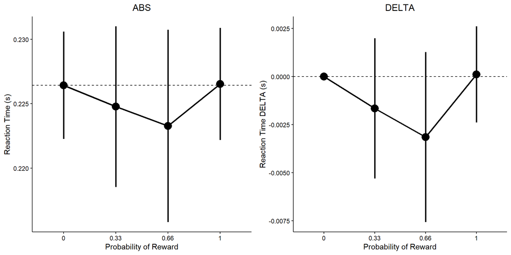

Table 4.2: Paired t-test post hoc comparisons with Holm-Bonferonni correction for Reaction Time.

|  | 1/3 | 2/3 | 1 |
| --- | --- | --- | --- |
| 0 | 1 | 1 | 1 |
| 1/3 | NA | 1 | 1 |
| 2/3 | NA | NA | 1 |

These are the uncorrected paired t-test values

Table 4.3: Paired t-test, no correction, for Reaction Time.

|  | 1/3 | 2/3 | 1 |
| --- | --- | --- | --- |
| 0 | 0.634 | 0.475 | 0.963 |
| 1/3 | NA | 0.299 | 0.371 |
| 2/3 | NA | NA | 0.332 |

#### 4.1.0.1 Summary Tables

Table 4.4: Summary data table for Reaction Time. Each row is a probability metric. This is compute subject average for each probability, then average the average. Data is shown as mean ± standard error (lower bound, upper bound) for the 95% confidence interval of that mean.

|  | Mean ± SE (lb, ub) |
| --- | --- |
| 0 | 0.226 ± 0.131 (-0.0298, 0.483) |
| 0.33 | 0.225 ± 0.13 (-0.0296, 0.479) |
| 0.66 | 0.223 ± 0.129 (-0.0294, 0.476) |
| 1 | 0.227 ± 0.131 (-0.0298, 0.483) |

#### 4.1.0.2 Comparison of 0% and 100% Reward

In a paired t test of subject averages, there WAS NOT a significant difference between 0% and 100% reward conditions for Reaction Time (p = 9.628e-01). .

In a ANOVA test of subject averages, there WAS NOT a significant difference between 0% and 100% reward conditions for Reaction Time (p = 9.836e-01). .

## 4.2 Effect of Trial

Over the course of the experiment, Reaction Time DECREASED with each subsequent trial. This was tested using an LMER of the form: Reaction Time = B*Trial + (1|Subject). We found B = -2.222e-05 and a p-value = 3.686e-14, and an intercept of 2.326e-01

The linear model used to predict effect of trial is shown below:
$$Outcome \sim B*Trial + (1|Subject)$$

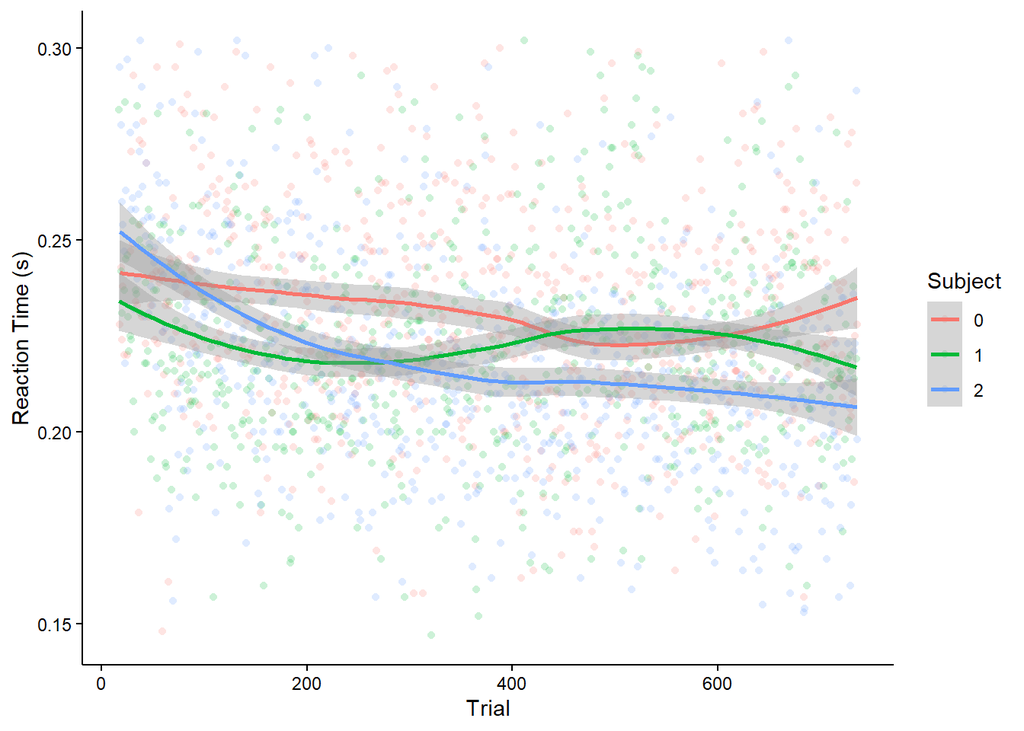

## 4.3 Reaction Time Following Reward

Using a paried t test, across subjects, the Reaction Time in trials following rewarded trials WAS NOT statistically different than trials following nonrewarded tirlas (p = 4.289e-01)

Using an ANOVA test, across subjects, the Reaction Time in trials following rewarded trials WAS NOT statistically different than trials following nonrewarded tirlas (p = 7.682e-01)

Table 4.5: Reaction Time P-Values for effect of Probability

|  | P-Value |
| --- | --- |
| T-test | 4.289e-01 |
| T-Test Prior==1 | 4.936e-04 |
| T-Test Prior==0 | 3.155e-04 |

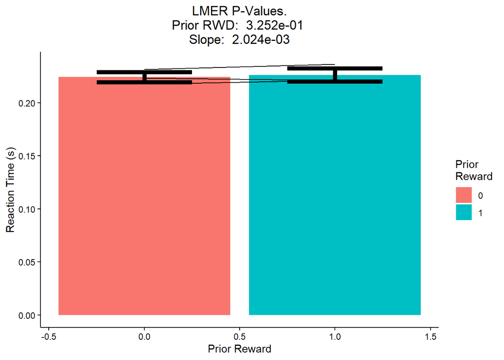

```
## boundary (singular) fit: see ?isSingular
## boundary (singular) fit: see ?isSingular
```

In an interacation LMER of probability of reward and prior reward with subject as a random intercept effect, Reaction Time WAS NOT affected by probability of reward (p = 7.021e-01) and WAS NOT affected by prior reward (p = 8.121e-01). An interaction of the two factors DID NOT affect Reaction Time (p = 6.600e-01)

Dividing the data set into two groups (trials following reward and trials not following reward) resulted in finding NO significant slope of probability (p = 8.177e-01) in trials that follow reward, but finding NO significant slope (p = 7.014e-01) in trials that do not follow reward.

The linear model used to predict the effect of probability and prior reward is:

$$Outcome \sim Probability + Prior Reward + Probability*Prior Reward + (1|Subject)$$

|  | P-Value | Slope |
| --- | --- | --- |
| Intercept | 0.000e+00 | 2.250e-01 ± 4.942e-03 |
| Prob Metric | 7.021e-01 | -1.489e-03 ± 3.893e-03 |
| Prior RWD | 8.121e-01 | 8.151e-04 ± 3.429e-03 |
| Interaction | 6.600e-01 | 2.428e-03 ± 5.519e-03 |
| Lm Prior == 1 Prob Effect | 8.177e-01 | 8.908e-04 ± 3.864e-03 |
| LM Prior == 0 Prob Effect | 7.014e-01 | -1.510e-03 ± 3.939e-03 |

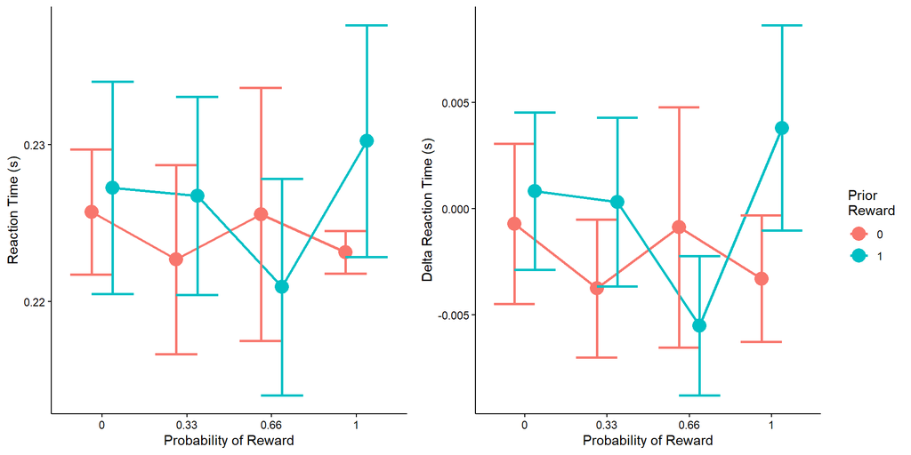

Table 4.7: RT Diff Prior P-Values for effect of Probability

|  | P-Value |
| --- | --- |
| T-test | 2.973e-01 |
| T-Test Prior==1 | 3.562e-01 |
| T-Test Prior==0 | 2.561e-01 |

To further examine this effect of prior reward on Reaction Time, the change in Reaction Time was determined from trial to trial. In the above graph Delta Reaction Time is the difference in Reaction Time of the current trial minus the previous trial (PV_(trial=n)-PV_(trial=n-1)). There WAS NOT a statistical difference between trials following and not following reward (paired t-test of subject averages, p = 2.973e-01). Reaction Time WAS NOT significantly different following reward (t-test of subject averages vs a mean of 0, p = 3.562e-01) and Reaction Time DID NOT significantly different following trials where they were not rewarded (t-test of subject averages vs a mean of 0, p = 2.561e-01).

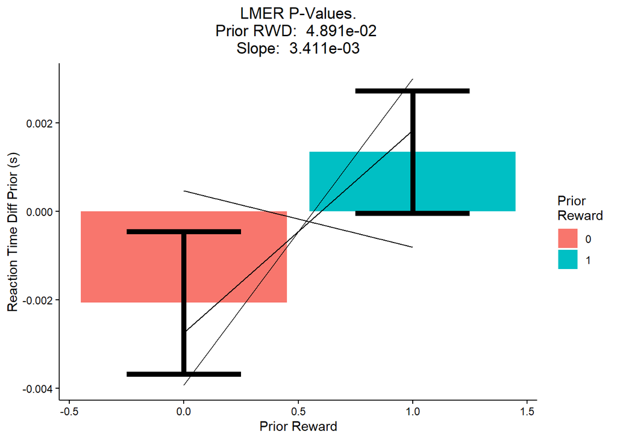

### 4.3.2 Interaction of Prior Reward and Change in Probability of Reward

Table 4.8: RT Diff Prior P-Values for effect of Diff Probability

|  | P-Value | Slope |
| --- | --- | --- |
| Intercept | 6.573e-01 | -1.020e-03 ± 2.299e-03 |
| Prob Metric | 3.870e-01 | -3.725e-03 ± 4.305e-03 |
| Prior RWD | 3.638e-01 | 2.969e-03 ± 3.269e-03 |
| Interaction | 3.389e-01 | 5.872e-03 ± 6.139e-03 |
| Lm Prior == 1 Prob Effect | 6.235e-01 | 2.147e-03 ± 4.374e-03 |
| LM Prior == 0 Prob Effect | 3.873e-01 | -3.725e-03 ± 4.308e-03 |

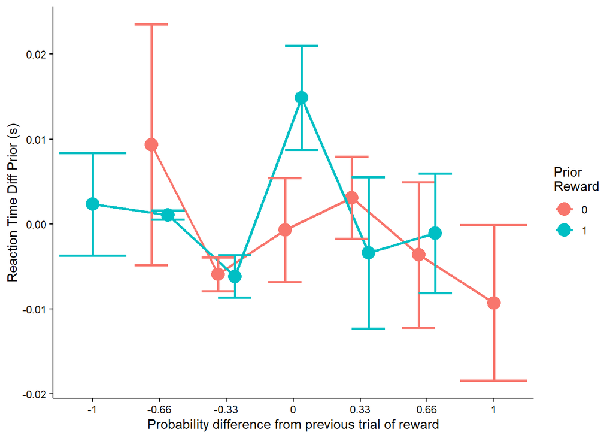

## 4.4 RPE

The linear model used to predict the effect of RPE and prior reward is:

$$Outcome \sim Probability + Prior Reward + Probability*Prior Reward + (1|Subject)$$

In an interacation LMER of RPE and prior reward with subject as a random intercept effect, Reaction Time WAS NOT affected by RPE (p = 1.002e-01) and WAS NOT affected by prior reward (p = 1.238e-01). An interaction of the two factors DID NOT affect Reaction Time (p = 1.693e-01)

Dividing the data set into two groups (trials following reward and trials not following reward) resulted in finding NO significant slope of RPE (p = 7.611e-01) in trials that follow reward, but finding NO significant slope (p = 1.003e-01) in trials that do not follow reward.

Table 4.9: Reaction Time P-Values for effect of RPE

|  | P-Value | Slope |
| --- | --- | --- |
| Intercept | 5.988e-02 | -4.907e-03 ± 2.608e-03 |
| Prob Metric | 1.002e-01 | -1.307e-02 ± 7.954e-03 |
| Prior RWD | 1.238e-01 | 5.714e-03 ± 3.713e-03 |
| Interaction | 1.693e-01 | 1.551e-02 ± 1.128e-02 |
| Lm Prior == 1 Prob Effect | 7.611e-01 | 2.432e-03 ± 7.999e-03 |
| LM Prior == 0 Prob Effect | 1.003e-01 | -1.307e-02 ± 7.956e-03 |

Table 4.9: Reaction Time P-Values for effect of RPE

|  | P-Value | Slope | Intercept |
| --- | --- | --- | --- |
| All Target LMER | 9.147e-01 | 4.514e-04 ± 4.216e-03 | -3.750e-04 |
| Target 1/4 LMER | 9.071e-01 | -6.443e-04 ± 5.519e-03 | 3.649e-04 |
| Target 1/4 ANOVA | 8.204e-01 | F val: 5.366e-02 |  |

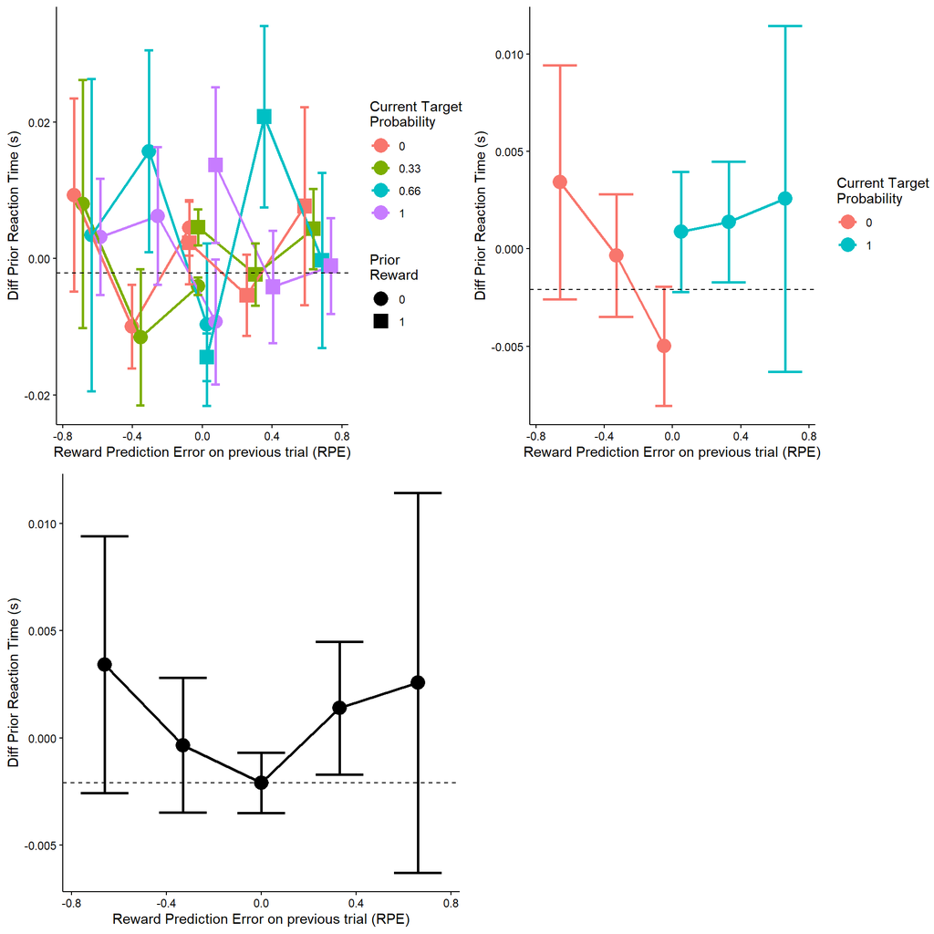

#### 4.4.0.1 T-Tests

Table 4.10: Paired t-test post hoc comparisons with Holm-Bonferonni correction for Reaction Time Diff Prior (m/s).

|  | -1/3 | 0 | 1/3 | 2/3 |
| --- | --- | --- | --- | --- |
| -2/3 | 1 | 1 | 1 | 1 |
| -1/3 | NA | 1 | 1 | 1 |
| 0 | NA | NA | 1 | 1 |
| 1/3 | NA | NA | NA | 1 |

These are the uncorrected paired t-test values

Table 4.11: Paired t-test, no correction, for Reaction Time Diff Prior (m/s).

|  | -1/3 | 0 | 1/3 | 2/3 |
| --- | --- | --- | --- | --- |
| -2/3 | 0.664 | 0.43 | 0.801 | 0.806 |
| -1/3 | NA | 0.532 | 0.305 | 0.79 |
| 0 | NA | NA | 0.347 | 0.626 |
| 1/3 | NA | NA | NA | 0.907 |

#### 4.4.0.2 Summary Table RPE

Table 4.12: Summary data table for Diff Prior Reaction Time. Each row is a probability metric. This is compute subject average for each probability, then average the average. Data is shown as mean ± standard error (lower bound, upper bound) for the 95% confidence interval of that mean.

|  | Mean ± SE (lb, ub) |
| --- | --- |
| -0.66 | 0.00341 ± 0.00197 (-0.000449, 0.00728) |
| -0.33 | -0.000342 ± -0.000197 (4.5e-05, -0.000729) |
| 0 | -0.0021 ± -0.00121 (0.000276, -0.00448) |
| 0.33 | 0.00139 ± 0.000801 (-0.000183, 0.00296) |
| 0.66 | 0.00257 ± 0.00148 (-0.000338, 0.00547) |

# 5 Maximum Excursion

## 5.1 Effect of Probability

```
## boundary (singular) fit: see ?isSingular
```

Maximum Excursion WAS significantly affected by probability of reward (p = 2.525e-02, slope = 2.341e-03). This was tested with an LMER with main outcome of probability and random effect of subject.

The equation below shows the linear model used:
$$Outcome \sim Probability + (1|Subject)$$

Table 5.1: Maximum Excursion P-Values for effect of Probability

|  | P-Value | Slope | Intercept |
| --- | --- | --- | --- |
| All Target LMER | 2.525e-02 | 2.341e-03 ± 1.046e-03 | 1.428e-01 |
| Target 1/4 LMER | 6.967e-02 | 2.310e-03 ± 1.273e-03 | 1.446e-01 |
| Target 1/4 ANOVA | 9.503e-01 | F val: 4.408e-03 |  |

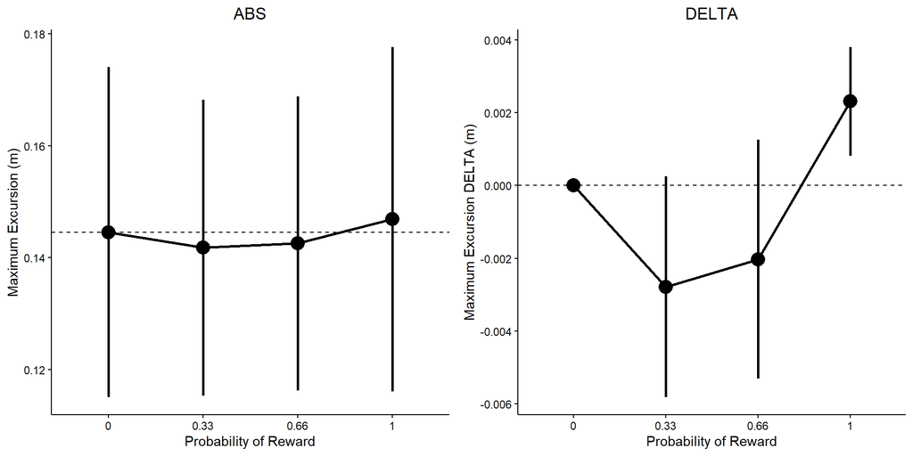

Table 5.2: Paired t-test post hoc comparisons with Holm-Bonferonni correction for Maximum Excursion.

|  | 1/3 | 2/3 | 1 |
| --- | --- | --- | --- |
| 0 | 1 | 1 | 1 |
| 1/3 | NA | 1 | 1 |
| 2/3 | NA | NA | 1 |

These are the uncorrected paired t-test values

Table 5.3: Paired t-test, no correction, for Maximum Excursion.

|  | 1/3 | 2/3 | 1 |
| --- | --- | --- | --- |
| 0 | 0.378 | 0.529 | 0.198 |
| 1/3 | NA | 0.208 | 0.293 |
| 2/3 | NA | NA | 0.377 |

#### 5.1.0.1 Summary Tables

Table 5.4: Summary data table for Maximum Excursion. Each row is a probability metric. This is compute subject average for each probability, then average the average. Data is shown as mean ± standard error (lower bound, upper bound) for the 95% confidence interval of that mean.

|  | Mean ± SE (lb, ub) |
| --- | --- |
| 0 | 0.145 ± 0.0835 (-0.019, 0.308) |
| 0.33 | 0.142 ± 0.0819 (-0.0187, 0.302) |
| 0.66 | 0.143 ± 0.0823 (-0.0188, 0.304) |
| 1 | 0.147 ± 0.0848 (-0.0193, 0.313) |

#### 5.1.0.2 Comparison of 0% and 100% Reward

In a paired t test of subject averages, there WAS NOT a significant difference between 0% and 100% reward conditions for Maximum Excursion (p = 1.980e-01). .

In a ANOVA test of subject averages, there WAS NOT a significant difference between 0% and 100% reward conditions for Maximum Excursion (p = 9.503e-01). .

## 5.2 Effect of Trial

Over the course of the experiment, Maximum Excursion INCREASED with each subsequent trial. This was tested using an LMER of the form: Maximum Excursion = B*Trial + (1|Subject). We found B = 2.806e-05 and a p-value = 0.000e+00, and an intercept of 1.334e-01

The linear model used to predict effect of trial is shown below:
$$Outcome \sim B*Trial + (1|Subject)$$

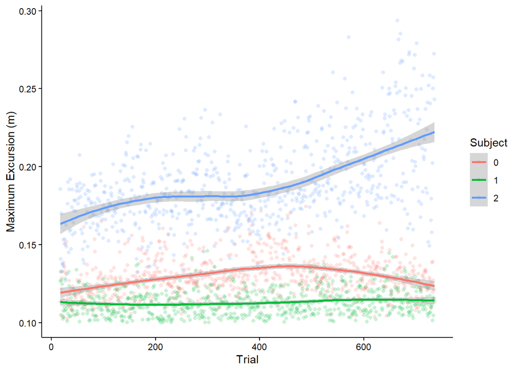

## 5.3 Maximum Excursion Following Reward

Using a paried t test, across subjects, the Maximum Excursion in trials following rewarded trials WAS NOT statistically different than trials following nonrewarded tirlas (p = 2.933e-01)

Using an ANOVA test, across subjects, the Maximum Excursion in trials following rewarded trials WAS NOT statistically different than trials following nonrewarded tirlas (p = 9.879e-01)

Table 5.5: Maximum Excursion P-Values for effect of Probability

|  | P-Value |
| --- | --- |
| T-test | 2.933e-01 |
| T-Test Prior==1 | 2.507e-02 |
| T-Test Prior==0 | 2.443e-02 |

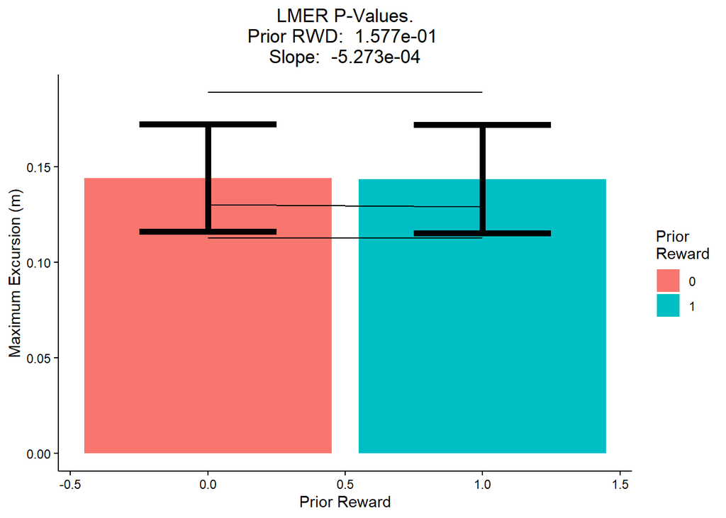

```
## boundary (singular) fit: see ?isSingular
## boundary (singular) fit: see ?isSingular
```

In an interacation LMER of probability of reward and prior reward with subject as a random intercept effect, Maximum Excursion WAS NOT affected by probability of reward (p = 7.074e-01) and WAS NOT affected by prior reward (p = 8.035e-02). An interaction of the two factors DID NOT affect Maximum Excursion (p = 8.824e-02)

Dividing the data set into two groups (trials following reward and trials not following reward) resulted in finding a significant slope of probability (p = 5.367e-03) in trials that follow reward, but finding NO significant slope (p = 7.139e-01) in trials that do not follow reward.

The linear model used to predict the effect of probability and prior reward is:

$$Outcome \sim Probability + Prior Reward + Probability*Prior Reward + (1|Subject)$$

|  | P-Value | Slope |
| --- | --- | --- |
| Intercept | 4.456e-10 | 1.439e-01 ± 2.307e-02 |
| Prob Metric | 7.074e-01 | 5.540e-04 ± 1.476e-03 |
| Prior RWD | 8.035e-02 | -2.273e-03 ± 1.300e-03 |
| Interaction | 8.824e-02 | 3.567e-03 ± 2.092e-03 |
| Lm Prior == 1 Prob Effect | 5.367e-03 | 4.112e-03 ± 1.477e-03 |
| LM Prior == 0 Prob Effect | 7.139e-01 | 5.438e-04 ± 1.483e-03 |

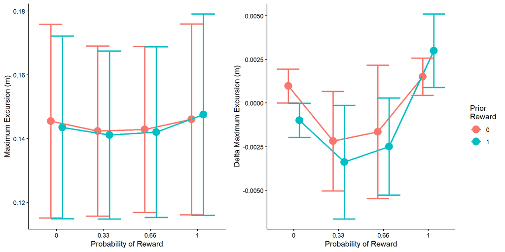

Table 5.7: Max_Ex Diff Prior P-Values for effect of Probability

|  | P-Value |
| --- | --- |
| T-test | 1.218e-02 |
| T-Test Prior==1 | 3.160e-02 |
| T-Test Prior==0 | 6.983e-03 |

To further examine this effect of prior reward on Maximum Excursion, the change in Maximum Excursion was determined from trial to trial. In the above graph Delta Maximum Excursion is the difference in Maximum Excursion of the current trial minus the previous trial (PV_(trial=n)-PV_(trial=n-1)). There WAS a statistical difference between trials following and not following reward (paired t-test of subject averages, p = 1.218e-02). Maximum Excursion WAS significantly different following reward (t-test of subject averages vs a mean of 0, p = 3.160e-02) and Maximum Excursion DID significantly different following trials where they were not rewarded (t-test of subject averages vs a mean of 0, p = 6.983e-03).

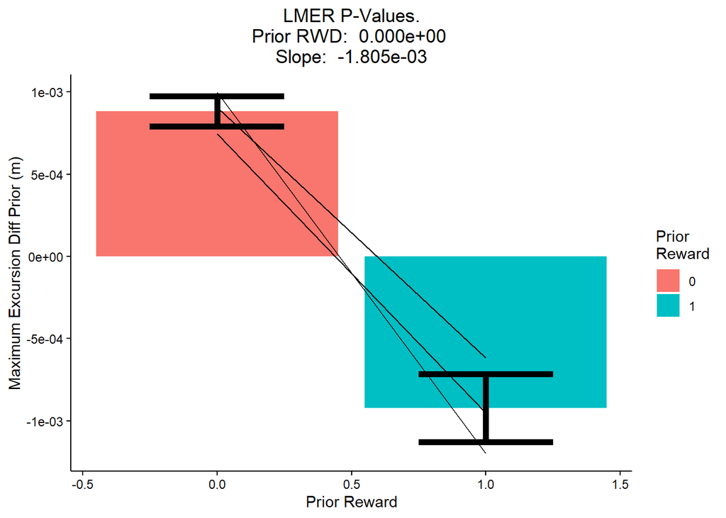

### 5.3.2 Interaction of Prior Reward and Change in Probability of Reward

Table 5.8: Max_Ex Diff Prior P-Values for effect of Diff Probability

|  | P-Value | Slope |
| --- | --- | --- |
| Intercept | 8.591e-02 | 1.289e-03 ± 7.507e-04 |
| Prob Metric | 3.035e-01 | -1.446e-03 ± 1.406e-03 |
| Prior RWD | 4.842e-01 | -7.467e-04 ± 1.067e-03 |
| Interaction | 9.174e-04 | 6.644e-03 ± 2.004e-03 |
| Lm Prior == 1 Prob Effect | 4.300e-04 | 5.198e-03 ± 1.476e-03 |
| LM Prior == 0 Prob Effect | 2.869e-01 | -1.446e-03 ± 1.358e-03 |

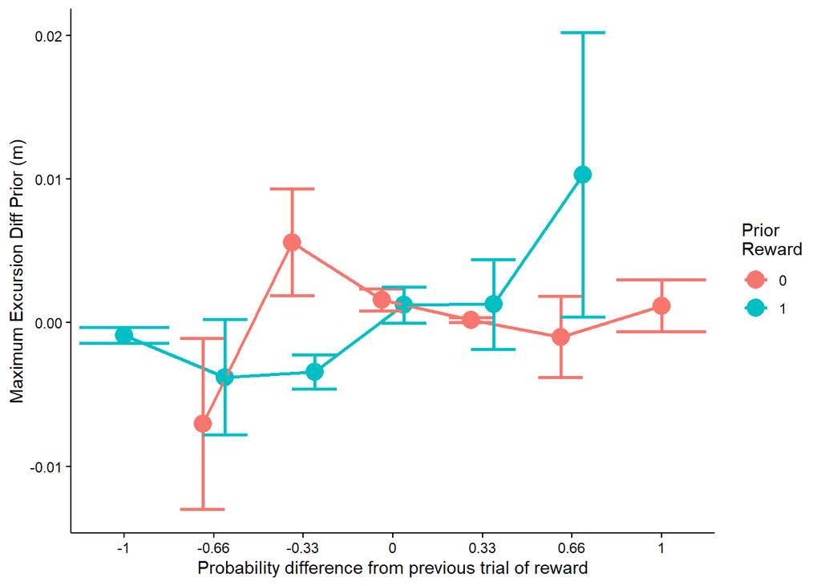

## 5.4 RPE

The linear model used to predict the effect of RPE and prior reward is:

$$Outcome \sim Probability + Prior Reward + Probability*Prior Reward + (1|Subject)$$

In an interacation LMER of RPE and prior reward with subject as a random intercept effect, Maximum Excursion WAS affected by RPE (p = 2.162e-02) and WAS NOT affected by prior reward (p = 1.432e-01). An interaction of the two factors DID affect Maximum Excursion (p = 1.475e-03)

Dividing the data set into two groups (trials following reward and trials not following reward) resulted in finding a significant slope of RPE (p = 3.370e-02) in trials that follow reward, but finding a significant slope (p = 1.711e-02) in trials that do not follow reward.

Table 5.9: Maximum Excursion P-Values for effect of RPE

|  | P-Value | Slope |
| --- | --- | --- |
| Intercept | 6.266e-01 | -4.148e-04 ± 8.526e-04 |
| Prob Metric | 2.162e-02 | -5.973e-03 ± 2.600e-03 |
| Prior RWD | 1.432e-01 | -1.777e-03 ± 1.214e-03 |
| Interaction | 1.475e-03 | 1.173e-02 ± 3.688e-03 |
| Lm Prior == 1 Prob Effect | 3.370e-02 | 5.754e-03 ± 2.709e-03 |
| LM Prior == 0 Prob Effect | 1.711e-02 | -5.973e-03 ± 2.505e-03 |

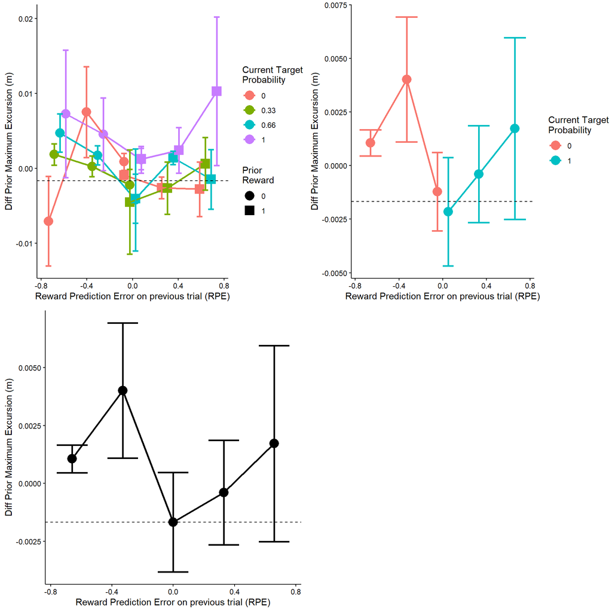

#### 5.4.0.1 T-Tests

Table 5.10: Paired t-test post hoc comparisons with Holm-Bonferonni correction for Maximum Excursion Diff Prior (m/s).

|  | -1/3 | 0 | 1/3 | 2/3 |
| --- | --- | --- | --- | --- |
| -2/3 | 1 | 1 | 1 | 1 |
| -1/3 | NA | 1 | 0.322 | 1 |
| 0 | NA | NA | 1 | 1 |
| 1/3 | NA | NA | NA | 1 |

These are the uncorrected paired t-test values

Table 5.11: Paired t-test, no correction, for Maximum Excursion Diff Prior (m/s).

|  | -1/3 | 0 | 1/3 | 2/3 |
| --- | --- | --- | --- | --- |
| -2/3 | 0.358 | 0.243 | 0.559 | 0.875 |
| -1/3 | NA | 0.301 | *0.0322 | 0.278 |
| 0 | NA | NA | 0.756 | 0.579 |
| 1/3 | NA | NA | NA | 0.323 |

#### 5.4.0.2 Summary Table RPE

Table 5.12: Summary data table for Diff Prior Maximum Excursion. Each row is a probability metric. This is compute subject average for each probability, then average the average. Data is shown as mean ± standard error (lower bound, upper bound) for the 95% confidence interval of that mean.

|  | Mean ± SE (lb, ub) |
| --- | --- |
| -0.66 | 0.00106 ± 0.000611 (-0.000139, 0.00225) |
| -0.33 | 0.00401 ± 0.00232 (-0.000528, 0.00855) |
| 0 | -0.00168 ± -0.000968 (0.000221, -0.00357) |
| 0.33 | -0.000399 ± -0.00023 (5.25e-05, -0.00085) |
| 0.66 | 0.00172 ± 0.000995 (-0.000227, 0.00367) |

# 6 Movement Time

## 6.1 Effect of Probability

```
## boundary (singular) fit: see ?isSingular
## boundary (singular) fit: see ?isSingular
```

Movement Duration WAS NOT significantly affected by probability of reward (p = 7.581e-01, slope = -2.679e-03). This was tested with an LMER with main outcome of probability and random effect of subject.

The equation below shows the linear model used:
$$Outcome \sim Probability + (1|Subject)$$

Table 6.1: Movement Duration P-Values for effect of Probability

|  | P-Value | Slope | Intercept |
| --- | --- | --- | --- |
| All Target LMER | 7.581e-01 | -2.679e-03 ± 8.700e-03 | 4.098e-01 |
| Target 1/4 LMER | 8.435e-01 | -1.646e-03 ± 8.340e-03 | 4.073e-01 |
| Target 1/4 ANOVA | 9.889e-01 | F val: 2.190e-04 |  |

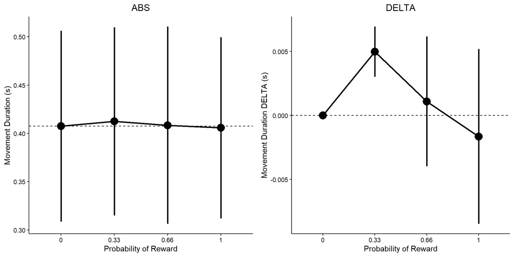

Table 6.2: Paired t-test post hoc comparisons with Holm-Bonferonni correction for Movement Duration.

|  | 1/3 | 2/3 | 1 |
| --- | --- | --- | --- |
| 0 | 0.537 | 1 | 1 |
| 1/3 | NA | 1 | 1 |
| 2/3 | NA | NA | 1 |

These are the uncorrected paired t-test values

Table 6.3: Paired t-test, no correction, for Movement Duration.

|  | 1/3 | 2/3 | 1 |
| --- | --- | --- | --- |
| 0 | 0.0895 | 0.816 | 0.796 |
| 1/3 | NA | 0.568 | 0.237 |
| 2/3 | NA | NA | 0.804 |

#### 6.1.0.1 Summary Tables

Table 6.4: Summary data table for Movement Duration. Each row is a probability metric. This is compute subject average for each probability, then average the average. Data is shown as mean ± standard error (lower bound, upper bound) for the 95% confidence interval of that mean.

|  | Mean ± SE (lb, ub) |
| --- | --- |
| 0 | 0.407 ± 0.235 (-0.0536, 0.868) |
| 0.33 | 0.412 ± 0.238 (-0.0543, 0.879) |
| 0.66 | 0.408 ± 0.236 (-0.0538, 0.871) |
| 1 | 0.406 ± 0.234 (-0.0534, 0.865) |

#### 6.1.0.2 Comparison of 0% and 100% Reward

In a paired t test of subject averages, there WAS NOT a significant difference between 0% and 100% reward conditions for Movement Duration (p = 7.958e-01). .

In a ANOVA test of subject averages, there WAS NOT a significant difference between 0% and 100% reward conditions for Movement Duration (p = 9.889e-01). .

## 6.2 Effect of Trial

Over the course of the experiment, Movement Duration DECREASED with each subsequent trial. This was tested using an LMER of the form: Movement Duration = B*Trial + (1|Subject). We found B = -1.409e-04 and a p-value = 0.000e+00, and an intercept of 4.615e-01

The linear model used to predict effect of trial is shown below:
$$Outcome \sim B*Trial + (1|Subject)$$

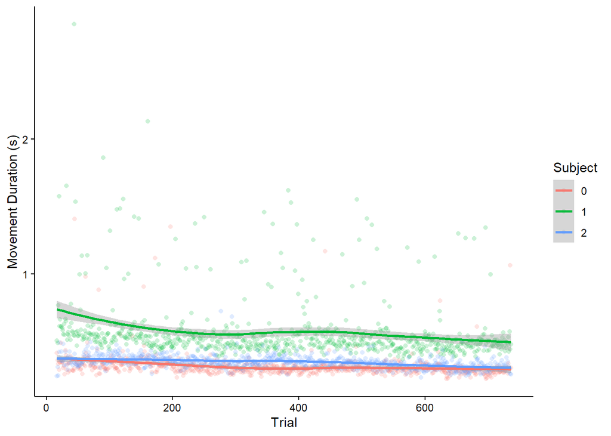

## 6.3 Movement Duration Following Reward

Using a paried t test, across subjects, the Movement Duration in trials following rewarded trials WAS NOT statistically different than trials following nonrewarded tirlas (p = 7.452e-01)

Using an ANOVA test, across subjects, the Movement Duration in trials following rewarded trials WAS NOT statistically different than trials following nonrewarded tirlas (p = 9.900e-01)

Table 6.5: Movement Duration P-Values for effect of Probability

|  | P-Value |
| --- | --- |
| T-test | 7.452e-01 |
| T-Test Prior==1 | 3.789e-02 |
| T-Test Prior==0 | 3.478e-02 |

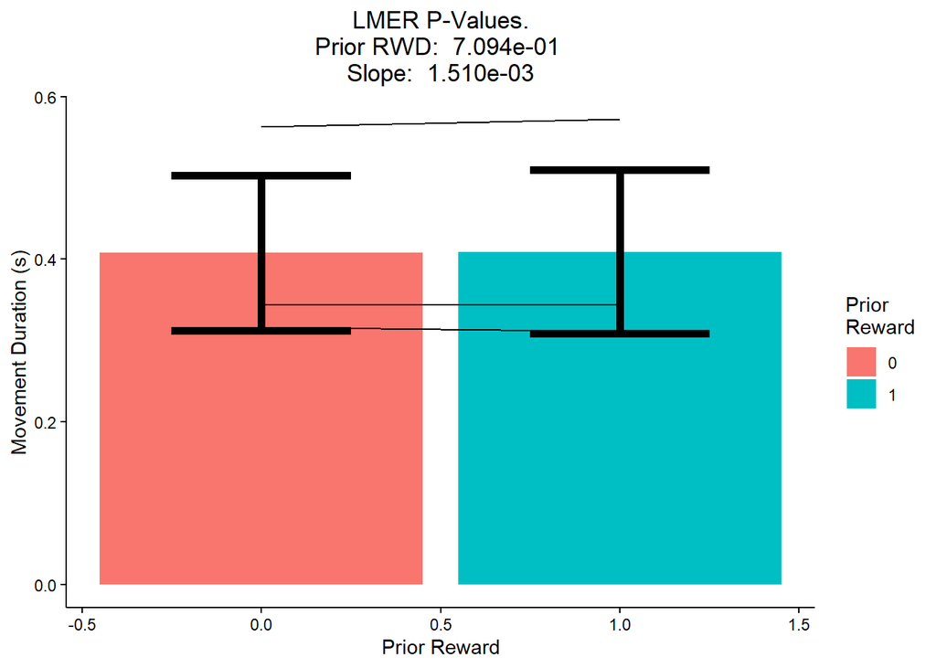

```
## boundary (singular) fit: see ?isSingular
## boundary (singular) fit: see ?isSingular
## boundary (singular) fit: see ?isSingular
## boundary (singular) fit: see ?isSingular
## boundary (singular) fit: see ?isSingular
## boundary (singular) fit: see ?isSingular
```

In an interacation LMER of probability of reward and prior reward with subject as a random intercept effect, Movement Duration WAS NOT affected by probability of reward (p = 2.270e-01) and WAS NOT affected by prior reward (p = 3.223e-01). An interaction of the two factors DID NOT affect Movement Duration (p = 1.595e-01)

Dividing the data set into two groups (trials following reward and trials not following reward) resulted in finding NO significant slope of probability (p = 4.234e-01) in trials that follow reward, but finding NO significant slope (p = 2.370e-01) in trials that do not follow reward.

The linear model used to predict the effect of probability and prior reward is:

$$Outcome \sim Probability + Prior Reward + Probability*Prior Reward + (1|Subject)$$

|  | P-Value | Slope |
| --- | --- | --- |
| Intercept | 2.400e-07 | 4.152e-01 ± 8.038e-02 |
| Prob Metric | 2.270e-01 | -1.484e-02 ± 1.228e-02 |
| Prior RWD | 3.223e-01 | -1.070e-02 ± 1.081e-02 |
| Interaction | 1.595e-01 | 2.449e-02 ± 1.741e-02 |
| Lm Prior == 1 Prob Effect | 4.234e-01 | 9.706e-03 ± 1.212e-02 |
| LM Prior == 0 Prob Effect | 2.370e-01 | -1.477e-02 ± 1.249e-02 |

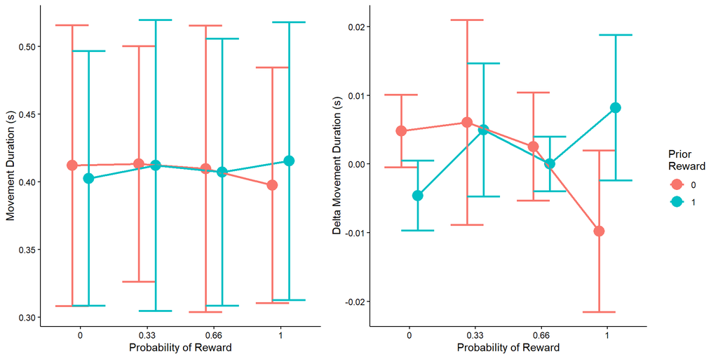